# IE423 Project Part 2

# Duygu Bedir - İpek Üstünboyacıoğlu

## Part 1

In this project after transforming our image to grey scale, we eliminated two channels since all channels have the same pixel value. We used 2-dimensional version of our image for the rest of the project.

In the first part, we have performed quality control operations by constructing x-bar chart for each row and column in order to identify out-of-control pixel values.

```
 num [1:400, 1:400] 0.8 0.792 0.804 0.714 0.702 ...
```

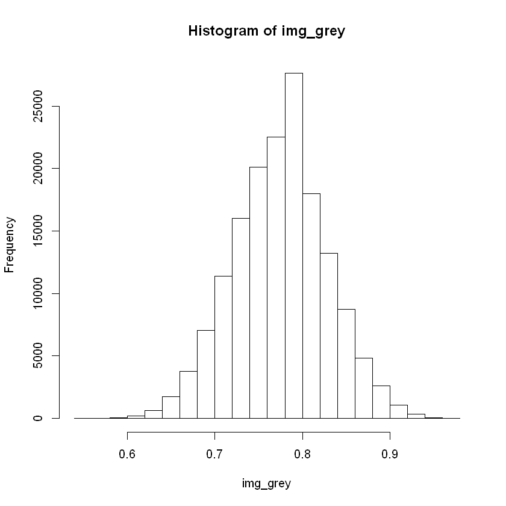

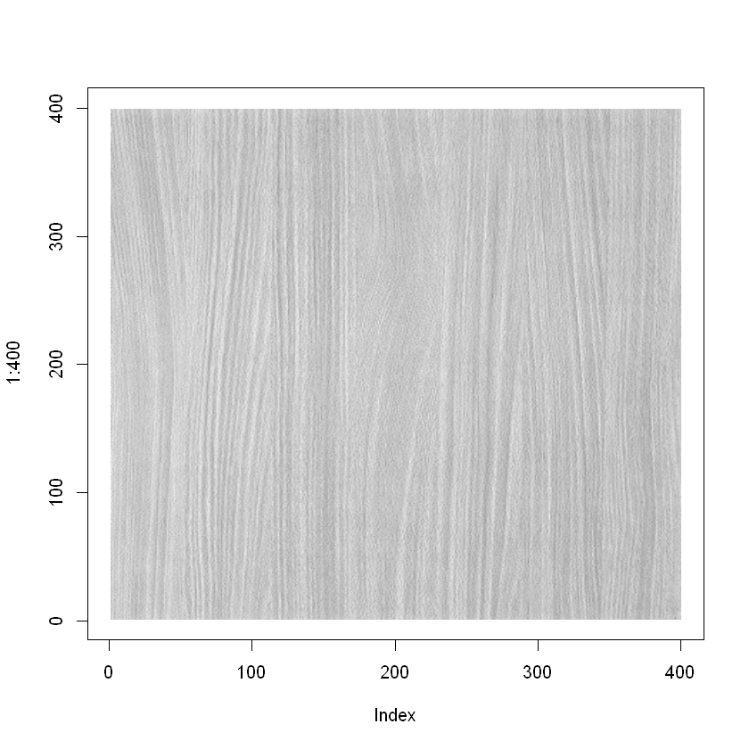

```r
library(jpeg)
img<-readJPEG("C:/Users/ipeku/Desktop/IE 423 P2/group_others_bw.jpeg")
img_grey<-img[,,1]
hist(img_grey)
str(img_grey)
plot(1:400, type='n')
rasterImage(img_grey, 1, 1, 400, 400)
```

For each row of the image, we calculated mean and standard deviation. Then, we calculated Upper Control Limit and Lower Control Limit by adding 3-sigma to the mean and substracting 3-sigma from mean. We used X-bar chart to identify out-of control pixels because we assumed that the distribution of the pixels are same horizontally and vertically and we want to identify pixel values that are far from the mean.

### a) Row-based Control Chart

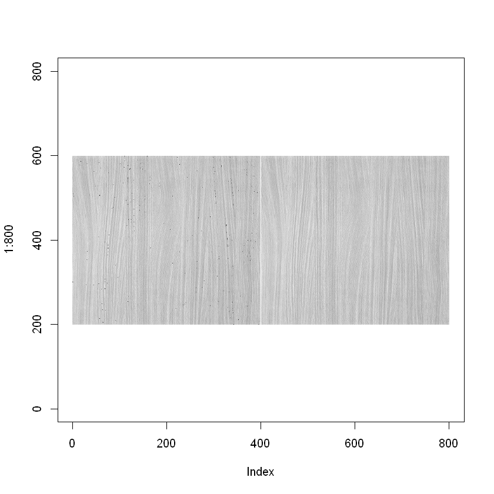

```r
avg_row<-rep(0,400)
sd_row<-rep(0,400)
UCL_row<-rep(0,400)
LCL_row<-rep(0,400)
for (i in 1:400){
  avg_row[i]<-sum(img_grey[i,])/400
  sd_row[i]<-sd(img_grey[i,])
  UCL_row[i]<-avg_row[i]+3*sd_row[i]
  LCL_row[i]<-avg_row[i]-3*sd_row[i]
}

for (i in 1:400){
  for(j in 1:400){
    if(img_grey[i,j]>UCL_row[i]){
     img_grey[i,j]=0
     }
    if(img_grey[i,j]<LCL_row[i]){
     img_grey[i,j]=0
    }
  }
}
plot(1:800, type='n')
rasterImage(img_grey, 0, 200, 399, 600)
rasterImage(img, 400, 200, 800, 600)
```

When we compared our new image with the original one, we observed more black dots on parts that the pattern is different from the whole image. Since we have a wooden surface, it is very reasonable to have irregular pattern, if we had a regular pattern on the whole image, we would expect less out-of-control pixels and less black dots.

#### Example x-bar chart for the 200th row:

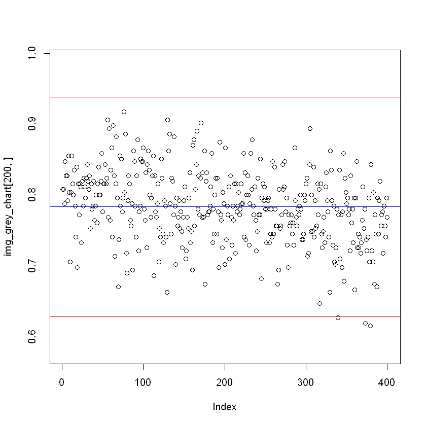

```r
img_grey_chart<-img[,,1]
CL = avg_row[200]
UCL = avg_row[200] + 3*sd_row[200]
LCL = avg_row[200] - 3*sd_row[200]
plot(img_grey_chart[200,], ylim = c(LCL-0.05,UCL+0.05))
abline(LCL,0,col = "red")
abline(UCL,0,col = "red")
abline(CL,0,col = "blue")
```

### b) Column-based Control Chart

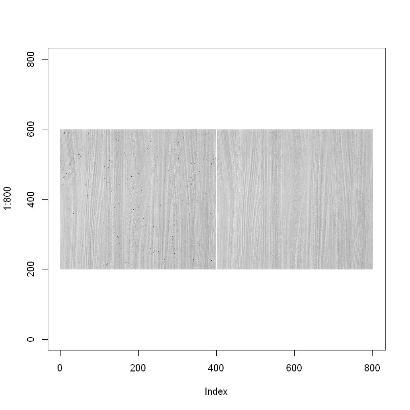

```r
img_grey2<-img[,,1]
avg_col<-rep(0,400)
sd_col<-rep(0,400)
UCL_col<-rep(0,400)
LCL_col<-rep(0,400)

for (i in 1:400){
  avg_col[i]<-sum(img_grey2[,i])/400
  sd_col[i]<-sd(img_grey2[,i])
  UCL_col[i]<-avg_col[i]+3*sd_col[i]
  LCL_col[i]<-avg_col[i]-3*sd_col[i]
}

for (i in 1:400){
  for(j in 1:400){
    if(img_grey2[j,i]>UCL_col[i]){
      img_grey2[j,i]=0
    }
    if(img_grey2[j,i]<LCL_col[i]){
      img_grey2[j,i]=0
    }
  }
}

plot(1:800, type='n')
rasterImage(img_grey2, 0, 200, 399, 600)
rasterImage(img, 400, 200, 800, 600)
```

Like the row-based model, we observed more black dots on irregular parts of the image. There are more black dots than the previous example. The reason of that could be the vertical pattern of the image. Since it has vertical pattern,shifts in the pattern affects the columns significantly.

#### Example x-bar chart for the 200th column:

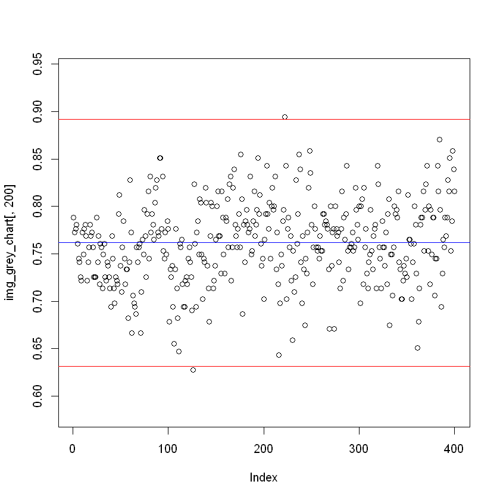

```r
img_grey_chart<-img[,,1]
CL2 = avg_col[200]
UCL2 = avg_col[200] + 3*sd_col[200]
LCL2 = avg_col[200] - 3*sd_col[200]
plot(img_grey_chart[,200], ylim = c(LCL2-0.05,UCL2+0.05))
abline(LCL2,0,col = "red")
abline(UCL2,0,col = "red")
abline(CL2,0,col = "blue")
```

## Part 2

```r
library(jpeg)
img<-readJPEG("C:/Users/ipeku/Desktop/IE 423 P2/group_others_bw.jpeg")
img_grey<-img[,,1]
str(img_grey)

memory.limit(size=90000000000)
window<-matrix(NA,1,2601)
data<-matrix(NA,122500,2601)

for(i in 1:350){
  for(j in 1:350){
    patch<-img_grey[i:(i+50),j:(j+50)]
    window<-as.vector(t(patch))
    data[(i-1)*350+j,1:2601]<-window[1:2601]
  }
}

data<-as.data.frame(data)
center<-data[,1301]
data<-data[,-1301]
data<-cbind(center,data)
head(data)
```

```
 num [1:400, 1:400] 0.8 0.792 0.804 0.714 0.702 ...
```

9e+10

| center | V1 | V2 | V3 | V4 | V5 | V6 | V7 | V8 | V9 | ... | V2592 | V2593 | V2594 | V2595 | V2596 | V2597 | V2598 | V2599 | V2600 | V2601 |
| --- | --- | --- | --- | --- | --- | --- | --- | --- | --- | --- | --- | --- | --- | --- | --- | --- | --- | --- | --- | --- |
| 0.6901961 | 0.8000000 | 0.8588235 | 0.7843137 | 0.7843137 | 0.8509804 | 0.8588235 | 0.7803922 | 0.8588235 | 0.8705882 | ... | 0.7686275 | 0.7607843 | 0.7254902 | 0.7803922 | 0.7137255 | 0.8431373 | 0.7686275 | 0.8078431 | 0.7803922 | 0.7764706 |
| 0.7607843 | 0.8588235 | 0.7843137 | 0.7843137 | 0.8509804 | 0.8588235 | 0.7803922 | 0.8588235 | 0.8705882 | 0.7529412 | ... | 0.7607843 | 0.7254902 | 0.7803922 | 0.7137255 | 0.8431373 | 0.7686275 | 0.8078431 | 0.7803922 | 0.7764706 | 0.8627451 |
| 0.7764706 | 0.7843137 | 0.7843137 | 0.8509804 | 0.8588235 | 0.7803922 | 0.8588235 | 0.8705882 | 0.7529412 | 0.7764706 | ... | 0.7254902 | 0.7803922 | 0.7137255 | 0.8431373 | 0.7686275 | 0.8078431 | 0.7803922 | 0.7764706 | 0.8627451 | 0.8313725 |
| 0.6862745 | 0.7843137 | 0.8509804 | 0.8588235 | 0.7803922 | 0.8588235 | 0.8705882 | 0.7529412 | 0.7764706 | 0.7960784 | ... | 0.7803922 | 0.7137255 | 0.8431373 | 0.7686275 | 0.8078431 | 0.7803922 | 0.7764706 | 0.8627451 | 0.8313725 | 0.8039216 |
| 0.8117647 | 0.8509804 | 0.8588235 | 0.7803922 | 0.8588235 | 0.8705882 | 0.7529412 | 0.7764706 | 0.7960784 | 0.7921569 | ... | 0.7137255 | 0.8431373 | 0.7686275 | 0.8078431 | 0.7803922 | 0.7764706 | 0.8627451 | 0.8313725 | 0.8039216 | 0.7254902 |
| 0.7098039 | 0.8588235 | 0.7803922 | 0.8588235 | 0.8705882 | 0.7529412 | 0.7764706 | 0.7960784 | 0.7921569 | 0.7254902 | ... | 0.8431373 | 0.7686275 | 0.8078431 | 0.7803922 | 0.7764706 | 0.8627451 | 0.8313725 | 0.8039216 | 0.7254902 | 0.8549020 |

Due to the excess memory need of the huge matrix, we changed the size of our memory and then implemented the multiple linear regression model which consists of 2600 predictors to predict the center value by using 122500 patches.

```r
model<-lm(center~.,data=data)
```

With this model, we can find the predicted values of center pixels and associated residuals. We plotted our model to interpret the distribution of the residuals. Due to the graphs below, it can be concluded that our residuals looks like normally distributed since residuals vs fitted plot shows that residuals are scattered around zero. Also, from Q-Q plot we can conclude that residuals are normally distributed.

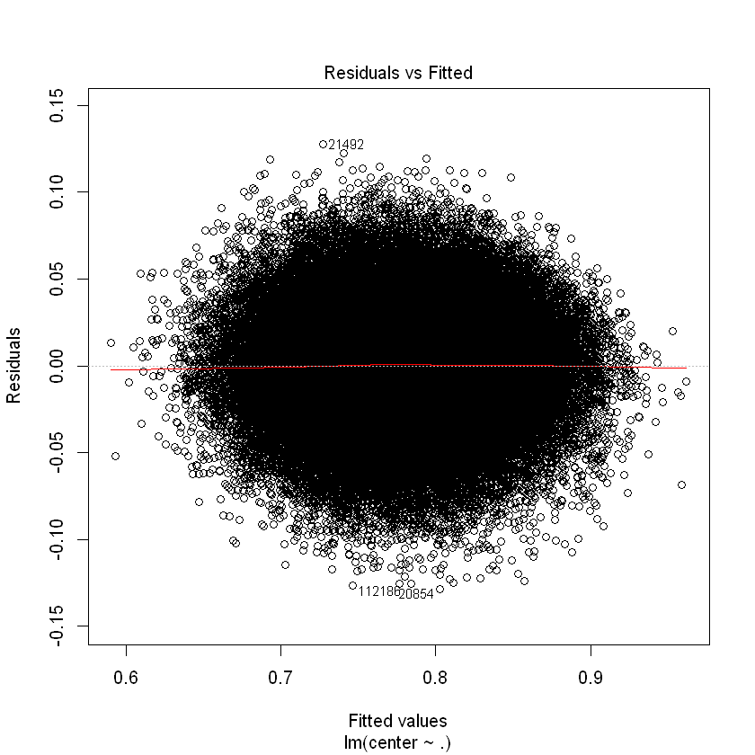

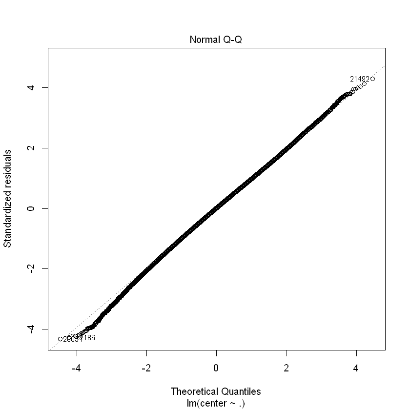

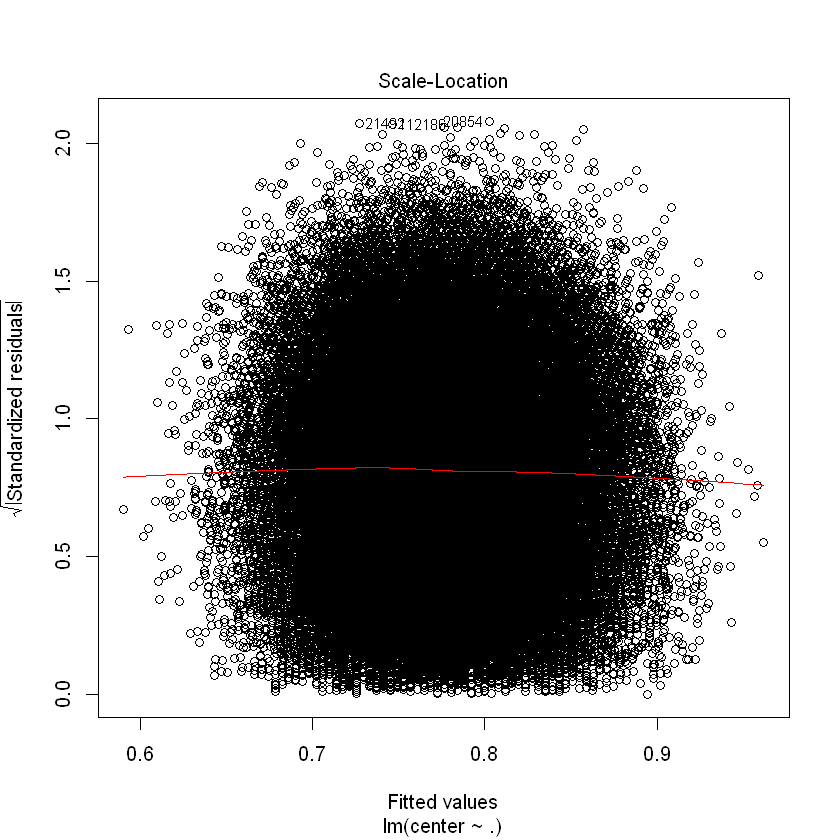

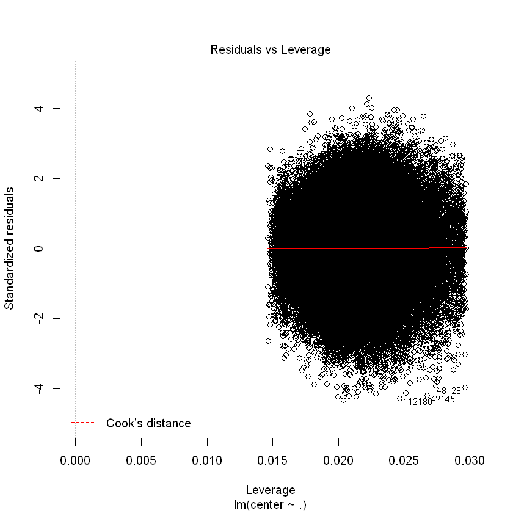

```r
plot(model)
```

Since we observed that our residuals are distributed normally, we constructed 6-sigma confidence interval on residuals. We plotted Residual Control Chart to be able to identify out-of control pixel values corresponding to out of control residuals.

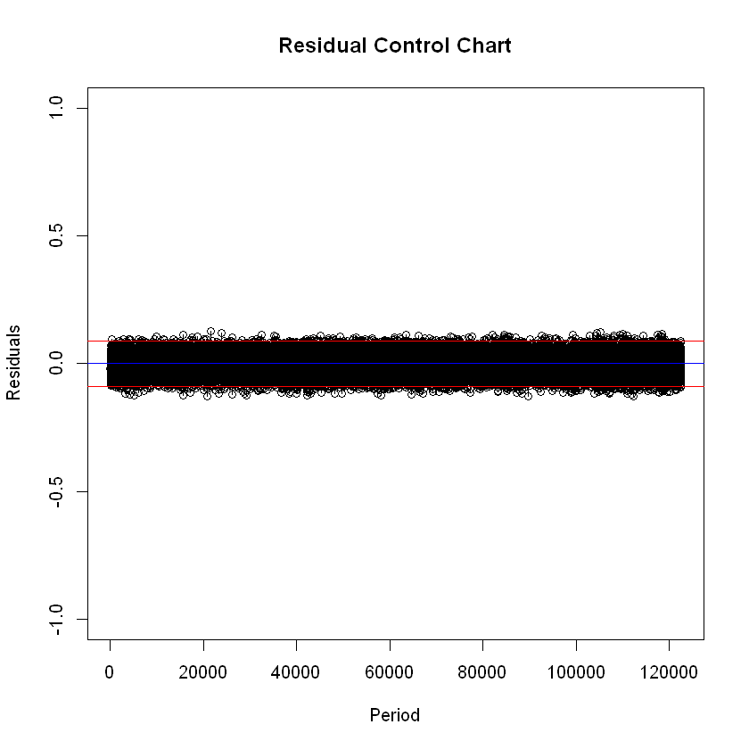

```r
plot(model$residuals, ylim = c(-1,1), main = "Residual Control Chart", xlab = "Period", ylab = "Residuals")
lines(model$residuals)
xbar <- mean(model$residuals)
std <- sd(model$residuals)
CL = xbar
UCL = xbar + 3*std
LCL = xbar - 3*std
abline(LCL,0,col = "red")
abline(UCL,0,col = "red")
abline(CL,0,col = "blue")
```

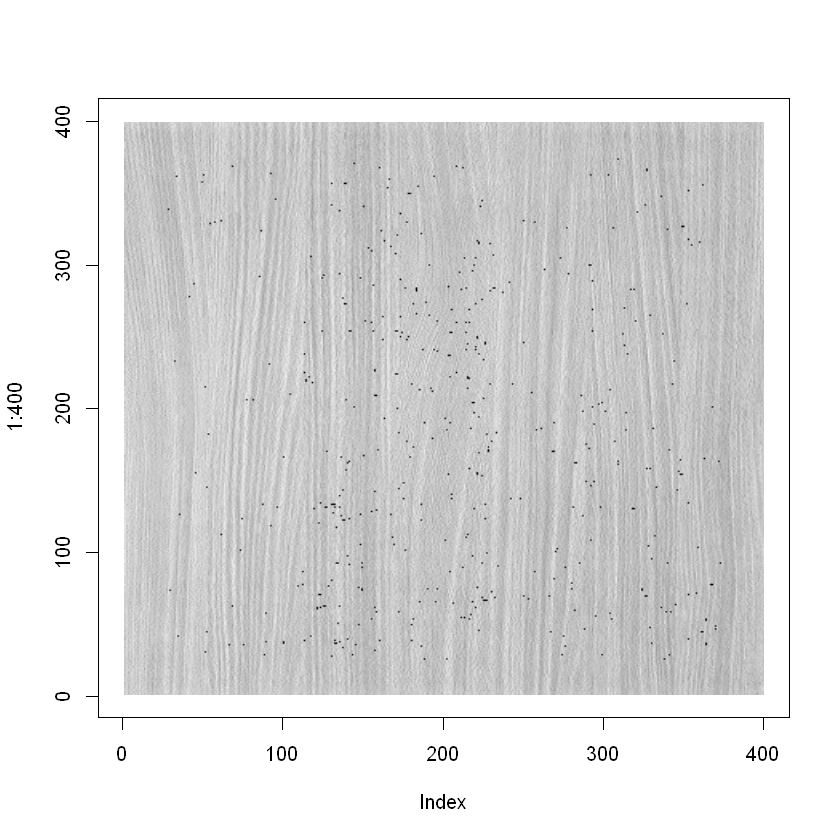

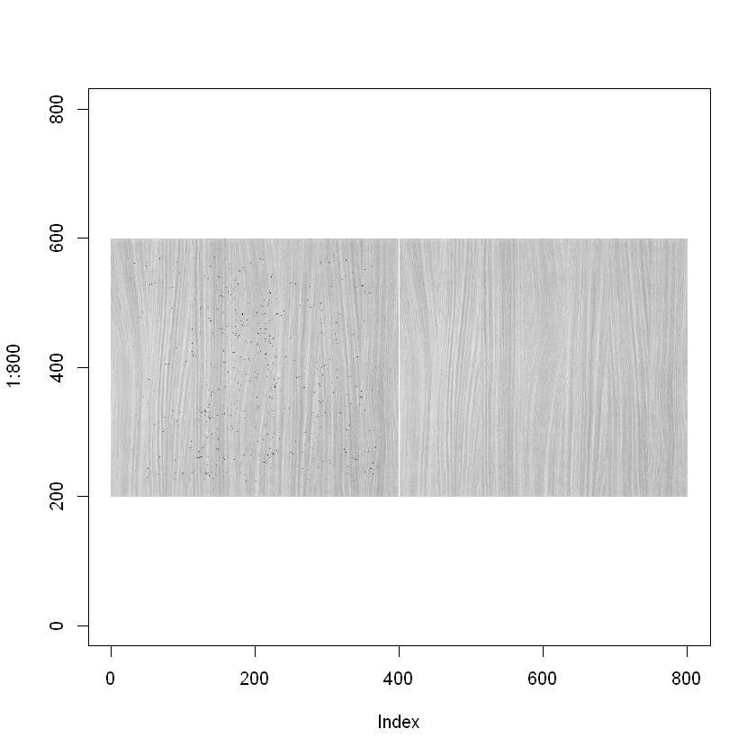

```r
for(i in 1:122500){
  if(model$residuals[i]>UCL){
    if((i%%350)==0){
      img_grey[((i/350)+25),((i-1)%%350)+26]=0
      }
    else{
    img_grey[((i-(i%%350))/350)+26,((i-1)%%350)+26]=0
   }
  }
  else if(model$residuals[i]<LCL){
    if((i%%350)==0){
      img_grey[((i/350)+25),((i-1)%%350)+26]=0
    }
    else{
      img_grey[((i-(i%%350))/350)+26,((i-1)%%350)+26]=0
    }
  }
}

plot(1:400, type='n')
rasterImage(img_grey, 1,1,400,400)

plot(1:800, type='n')
rasterImage(img_grey, 0, 200, 399, 600)
rasterImage(img, 400, 200, 800, 600)
```

After the model is successfully constructed, we used the model residuals to find the pixels above or below control limits and converted them to pure black color. To do that, we implemented a for loop to change the values of the pixels in the original image which correspond to the out-of-control-limit-valued pixels in the vector including all of the pixels of all the patches. After this change, we plotted our final image and saw a square started from 26 to 375 In both directions, including black dots.

Along this homework we ignored the problem of autocorrelation. However, since our image has a texture, the pixel values are related to each other, not independent.Thus, in order to eliminate this problem, one can use several methods. We can differentiate consecutive pixels and use lagged variables to construct model. Also, in order to understand the each effect of the predictor to the model, we can add the predictors not altogether but one after another to understand their effects to the model more vividly and then decide whether to add the predictor to the model or not. By doing so, we can identify the related predictors and eliminate some of them. But this solution has some drawbacks too. For instance, we don't know how to start implementing the model with which predictor first. It leads to an heuristic solution. In addition to that, adding the predictors one by one and deciding to keep them according to their effects is a time consuming process since we have 2600 predictors. This is hard to implement especially if we are dealing with big datasets.